# Assignment 6_Group 6

Christina Huang, Jiani Yang, Yixiong Xu, Mahshad Davoodifard, Yujie Yang, Zhixin Zheng, Xi Gu, Jiaao

12/6/2020

### Task I

- You will be working in groups on a quantified student project
- Download the *Sensor Kinetics Pro* app to your [iOS](https://itunes.apple.com/us/app/sensor-kinetics-pro/id623633248?mt=8) or [Android](https://play.google.com/store/apps/details?id=com.innoventions.sensorkineticspro&hl=en) device (or similar gyroscope measuring app)
- Split into subgroups with each subgroup investigating one measures available in the app
- Each subgroup shopuld report back aafter 20min with what they have learned

##Please see https://docs.google.com/document/d/1bkCk6XsSL_e085Si-h1YvBbpkEhOxEwpKKUIGNYZ7VA/edit

### Task II

- In consultation with your group select a physical activity that: a) can be measured using the app, b) has a concrrete, sontinuous, countable outcome and c) some members of the group are experts and some are novices at - If you are looking for inspiration you can find previous student projects below.
- Collect measurements for all members of the group performing the task using the app
- Create a Github repo where you can store and share your data
- Using K-means, can you identify the novices from the experts using only the app data?

- Visualize your results using ggplot2

```r
library(tidyr)
library(dplyr)
```

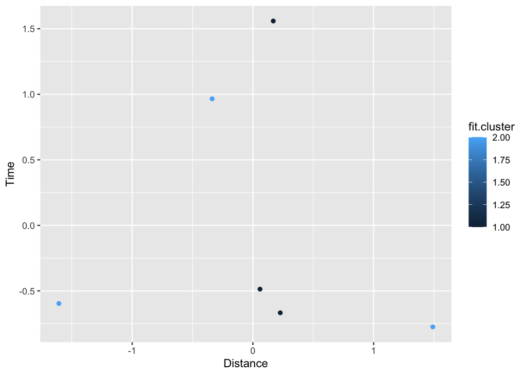

```r
library(ggplot2)
library(readr)
library(GGally)
D1 <- read_csv("Group 6  data.csv")
D2 <- read_csv("distance.csv")
D3 <- merge(D1, D2)
D3 <- D3[,-1]
D3 <- scale(D3)
fit <- kmeans(D3, 2)
D4 <- data.frame(D3, fit$cluster)
ggplot(D4, aes(distance, time, colour = fit.cluster)) + geom_point() + xlab("Distance") + ylab("Time")
```

### Task III

- Devise five questions on a five point Likert scale that ask members of your group about their experience with your chosen task
- Collect data from all members of your group
- Run a PCA analysis on the data
- What does PC1 represent in your analysis?

- Visualize the PC1 results for each member of your group

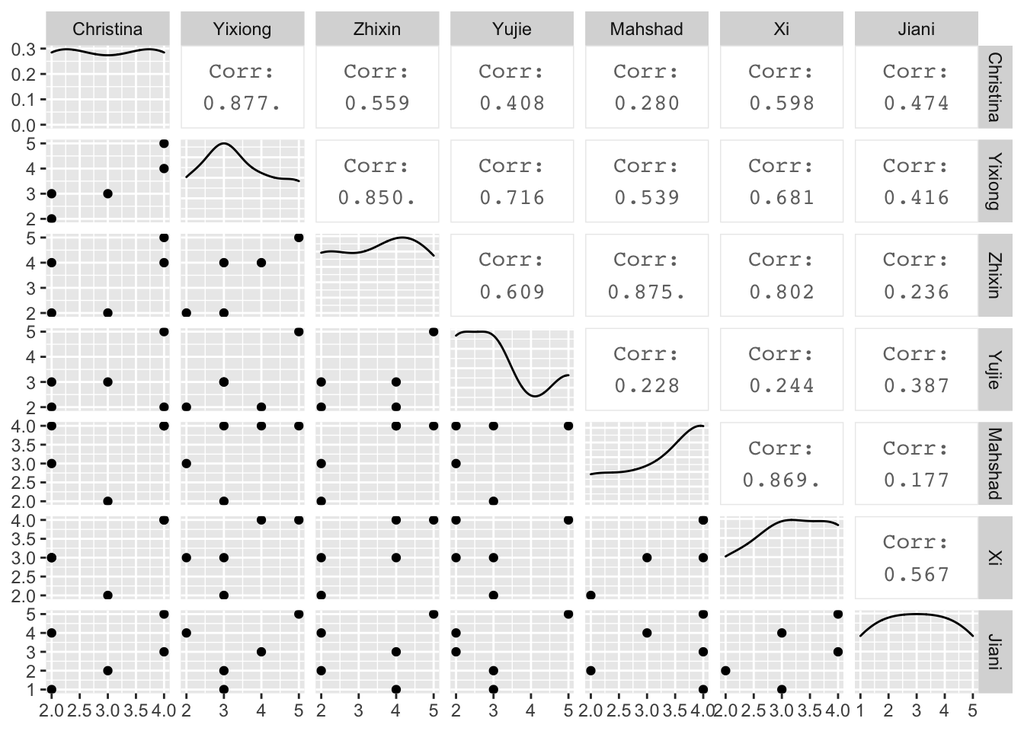

```r
K1 <- read.csv("survey.csv")
K1 <- K1[1:5,]
ggpairs(K1, 2:8, progress = FALSE)
```

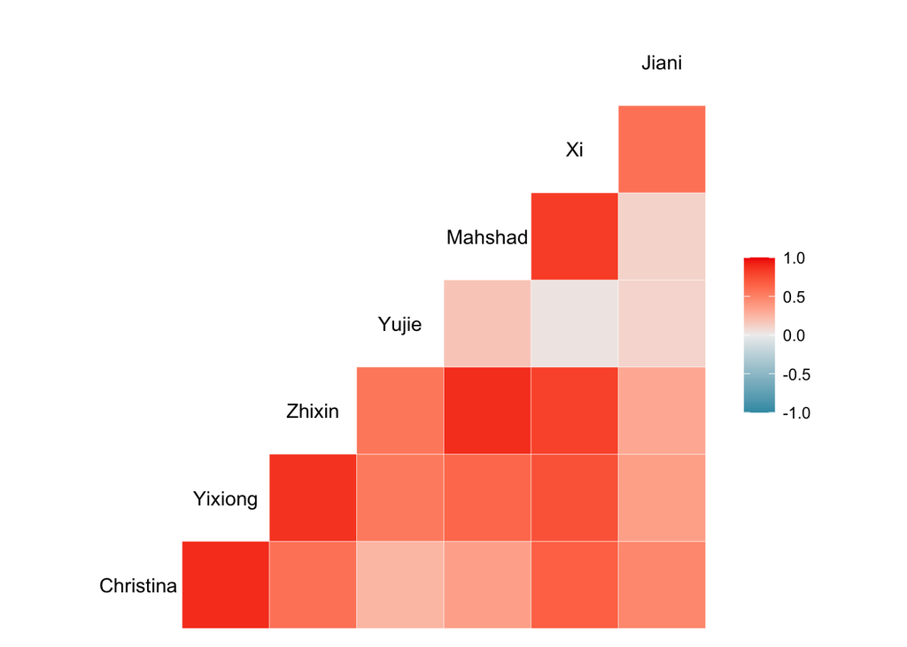

```r
ggcorr(K1[,-1], method = c("everything", "spearman"))
```

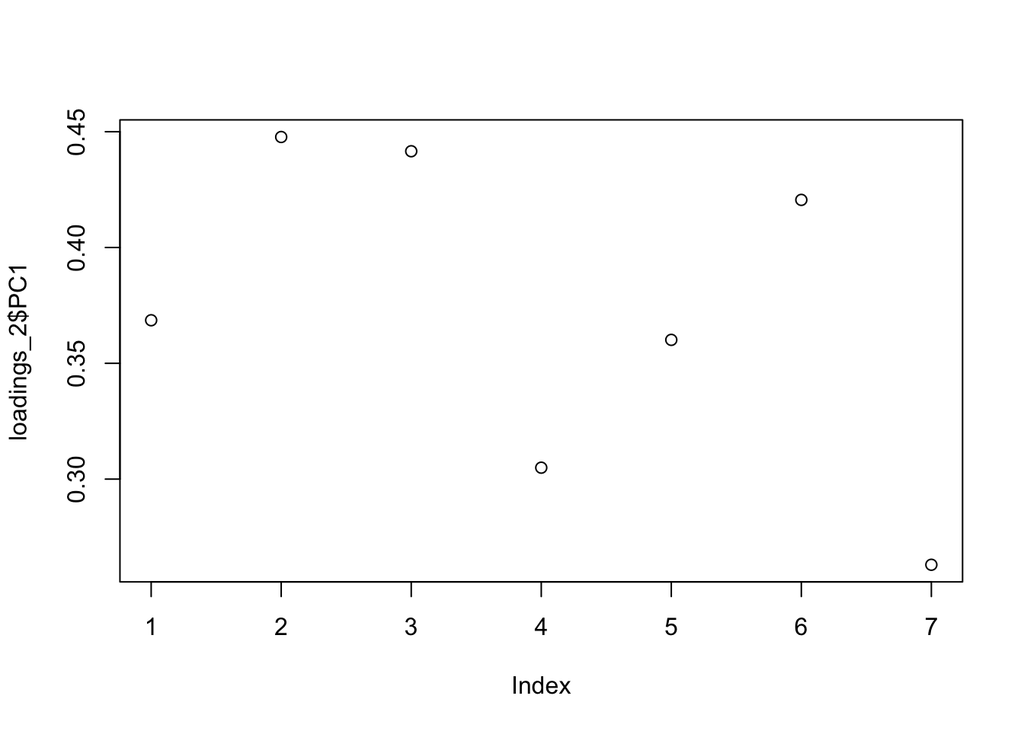

```r
K2 <- K1[,-1]
pca <- prcomp(K2, scale. = TRUE)
loadings <- abs(pca$rotation)
loadings_2 <- data.frame(loadings)
#Visualize the PC1 results for each member of your group
plot(loadings_2$PC1, type = "points")
```

### Task IV

- If you could only choose one thing to predict the score for each member of your group (raw data variable, a cluster or a PC) what would it be and why?

### We choose raw distance and time variables to predict the score for each member of our group. We think that both time and distance as raw data variables can be good predictors of novice and expert groups in our study. Based on the data and the nature of the exercise we implemented, we think that if you are an expert, you can hold up the position for a longer time and vice versa. We defined the distance based on the following:

### Distance Formula: The distance between two points is the length of the path connecting them. The shortest path distance is a straight line. In a 3 dimensional plane, the distance between points (X1, Y1, Z1) and (X2, Y2, Z2) please find the formula in the google doc.

- Create a visualization that supports your conclusion

```r
D5 <- D3[, c(1,5)]
cor(D5)
```

```
##                 time    distance
## time      1.00000000 -0.08780678
## distance -0.08780678  1.00000000
```

- Based on your conclusion devise an intervention that would help novice members of your group imporve their performance

### We will recommend novice members of our group to move less while performing the Hollow Body Hold.